# Expore and Summarize Physicochemical Property Data for Whie Wine Quality

### July 2017, by Jude Moon

# 1.Overview

In this project, I will use a white wine quality data set for [Portuguese “Vinho Verde” wine](http://www.vinhoverde.pt/en/about-vinho-verde), whose data were collected and published by [Cortez et al (2009)](http://www.sciencedirect.com/science/article/pii/S0167923609001377?via%3Dihub). This tidy data set contains 4,898 white wines with 11 variables on quantifying the physicochemical properties of each wine. At least 3 wine experts rated the quality of each wine, providing a rating between 0 (very bad) and 10 (very excellent). Details and units of the variables are provided [here](https://s3.amazonaws.com/udacity-hosted-downloads/ud651/wineQualityInfo.txt). The objectives of the analysis is to explore data to determine (1) whether any relationship between the physicochemical properties and sensory quality exists and (2) if so, which physicochemical properties are the most effective to describe quality, in other words, which properties are highly correlated with the quality score.

# 2. Analysis

## 2.1.2 Univariate Plots Section

### Data Summary

#### What are the data types of the columns?

```
## 'data.frame':    4898 obs. of  13 variables:
##  $ X                   : int  1 2 3 4 5 6 7 8 9 10 ...
##  $ fixed.acidity       : num  7 6.3 8.1 7.2 7.2 8.1 6.2 7 6.3 8.1 ...
##  $ volatile.acidity    : num  0.27 0.3 0.28 0.23 0.23 0.28 0.32 0.27 0.3 0.22 ...
##  $ citric.acid         : num  0.36 0.34 0.4 0.32 0.32 0.4 0.16 0.36 0.34 0.43 ...
##  $ residual.sugar      : num  20.7 1.6 6.9 8.5 8.5 6.9 7 20.7 1.6 1.5 ...
##  $ chlorides           : num  0.045 0.049 0.05 0.058 0.058 0.05 0.045 0.045 0.049 0.044 ...
##  $ free.sulfur.dioxide : num  45 14 30 47 47 30 30 45 14 28 ...
##  $ total.sulfur.dioxide: num  170 132 97 186 186 97 136 170 132 129 ...
##  $ density             : num  1.001 0.994 0.995 0.996 0.996 ...
##  $ pH                  : num  3 3.3 3.26 3.19 3.19 3.26 3.18 3 3.3 3.22 ...
##  $ sulphates           : num  0.45 0.49 0.44 0.4 0.4 0.44 0.47 0.45 0.49 0.45 ...
##  $ alcohol             : num  8.8 9.5 10.1 9.9 9.9 10.1 9.6 8.8 9.5 11 ...
##  $ quality             : int  6 6 6 6 6 6 6 6 6 6 ...
```

All columns are numeric or continuous, except X and quality. X is wine sample ID, so changing to factor data type would make more sense.

#### What are the data ranges of variables?

```
##        X        fixed.acidity    volatile.acidity  citric.acid
##  1      :   1   Min.   : 3.800   Min.   :0.0800   Min.   :0.0000
##  2      :   1   1st Qu.: 6.300   1st Qu.:0.2100   1st Qu.:0.2700
##  3      :   1   Median : 6.800   Median :0.2600   Median :0.3200
##  4      :   1   Mean   : 6.855   Mean   :0.2782   Mean   :0.3342
##  5      :   1   3rd Qu.: 7.300   3rd Qu.:0.3200   3rd Qu.:0.3900
##  6      :   1   Max.   :14.200   Max.   :1.1000   Max.   :1.6600
##  (Other):4892
##  residual.sugar     chlorides       free.sulfur.dioxide
##  Min.   : 0.600   Min.   :0.00900   Min.   :  2.00
##  1st Qu.: 1.700   1st Qu.:0.03600   1st Qu.: 23.00
##  Median : 5.200   Median :0.04300   Median : 34.00
##  Mean   : 6.391   Mean   :0.04577   Mean   : 35.31
##  3rd Qu.: 9.900   3rd Qu.:0.05000   3rd Qu.: 46.00
##  Max.   :65.800   Max.   :0.34600   Max.   :289.00
##
##  total.sulfur.dioxide    density             pH          sulphates
##  Min.   :  9.0        Min.   :0.9871   Min.   :2.720   Min.   :0.2200
##  1st Qu.:108.0        1st Qu.:0.9917   1st Qu.:3.090   1st Qu.:0.4100
##  Median :134.0        Median :0.9937   Median :3.180   Median :0.4700
##  Mean   :138.4        Mean   :0.9940   Mean   :3.188   Mean   :0.4898
##  3rd Qu.:167.0        3rd Qu.:0.9961   3rd Qu.:3.280   3rd Qu.:0.5500
##  Max.   :440.0        Max.   :1.0390   Max.   :3.820   Max.   :1.0800
##
##     alcohol         quality
##  Min.   : 8.00   Min.   :3.000
##  1st Qu.: 9.50   1st Qu.:5.000
##  Median :10.40   Median :6.000
##  Mean   :10.51   Mean   :5.878
##  3rd Qu.:11.40   3rd Qu.:6.000
##  Max.   :14.20   Max.   :9.000
##
```

The data range of each variable varies, e.g., volatile.acidity ranges from 0.08 to 1.1 while total.sulfur.dioxide ranges from 9 to 440. This suggests that data transformation such as standardization might be required to compare two variables.

### Extract numeric variables only to create a subset dataframe

```
##  [1] "fixed.acidity"        "volatile.acidity"     "citric.acid"
##  [4] "residual.sugar"       "chlorides"            "free.sulfur.dioxide"
##  [7] "total.sulfur.dioxide" "density"              "pH"
## [10] "sulphates"            "alcohol"              "quality"
```

#### Is there any missing values (na) or any zero values?

```
##      X           fixed.acidity   volatile.acidity citric.acid
##  Mode :logical   Mode :logical   Mode :logical    Mode :logical
##  FALSE:4898      FALSE:4898      FALSE:4898       FALSE:4879
##  NA's :0         NA's :0         NA's :0          TRUE :19
##                                                   NA's :0
##  residual.sugar  chlorides       free.sulfur.dioxide total.sulfur.dioxide
##  Mode :logical   Mode :logical   Mode :logical       Mode :logical
##  FALSE:4898      FALSE:4898      FALSE:4898          FALSE:4898
##  NA's :0         NA's :0         NA's :0             NA's :0
##
##   density            pH          sulphates        alcohol
##  Mode :logical   Mode :logical   Mode :logical   Mode :logical
##  FALSE:4898      FALSE:4898      FALSE:4898      FALSE:4898
##  NA's :0         NA's :0         NA's :0         NA's :0
##
##   quality
##  Mode :logical
##  FALSE:4898
##  NA's :0
##
```

This is no missing value. Variable citric.acid has 19 zeros. I will assume that they are true zeros.

### Quality score: response variable or label feature

#### Can I engineer this variable simpler to interpret?

I will create categorical variables of quality which is integer variable ranged from 3 to 9. One way is to convert into 7 classes (called **quality.order**) and the other is into 3 classes(called **quality.con** and **quality.lib**), where I can simply interpret as bad, ok, and good quality.

```
##  Ord.factor w/ 7 levels "3"<"4"<"5"<"6"<..: 4 4 4 4 4 4 4 4 4 4 ...
```

#### What is distribution of quality?

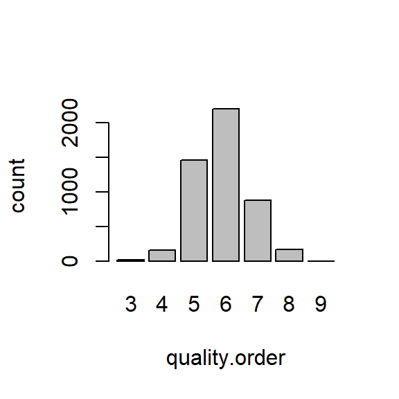

```
## [[1]]
## [1] "% of each group"
##
## [[2]]
## col
##          3          4          5          6          7          8
##  0.4083299  3.3278889 29.7468354 44.8754594 17.9665169  3.5728869
##          9
##  0.1020825
```

Quality is normally distributed. Quality score 6 is the most common quality for white wines (45%). Most white wines have a quality score between 5 and 6, which accounting for 75% of the total. If I predict that a product of white wine is in quality of 5 or 6, there will be 75% chance to be correct. White wines with a quality score between 5 and 7 and that between 4 and 8 are 92.6% and 99.5% respectively.

#### What are the distributions of 3-classes variables?

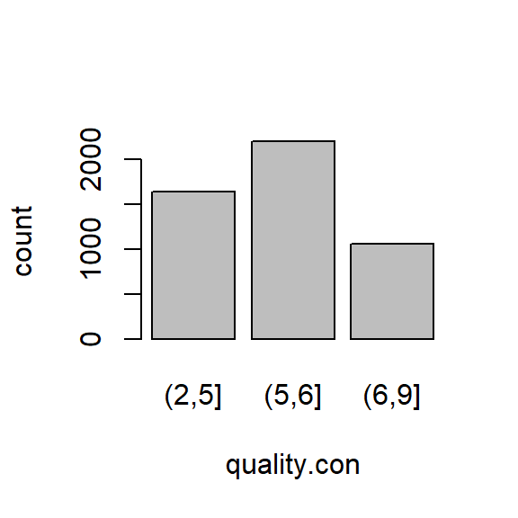

```
## [[1]]
## [1] "% of each group"
##
## [[2]]
## col
##    (2,5]    (5,6]    (6,9]
## 33.48305 44.87546 21.64149
```

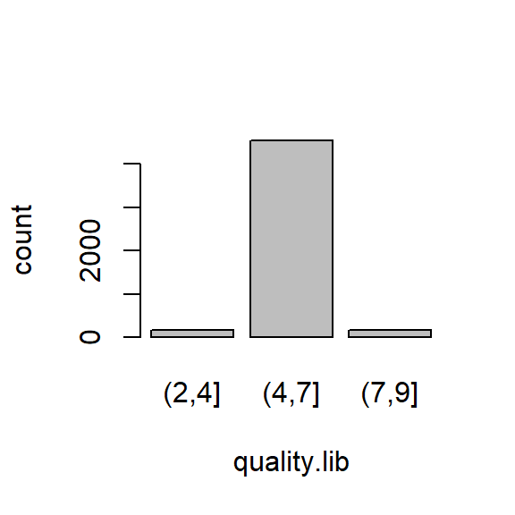

```
## [[1]]
## [1] "% of each group"
##
## [[2]]
## col
##     (2,4]     (4,7]     (7,9]
##  3.736219 92.588812  3.674969
```

I created 2 new variables; each includes 3-classes. One is that I named **quality.con** which cuts off the quality in a conservative way. This considers that wines with the score <6 are low quality, 6 are medium quality, and >6 are high quality.

The other I named **quality.lib** separates quality in a liberal way, where wine with a wide ranged score from 5 to 7 are considered as ok quality, <5 are low quality, and >7 are high quality.

The distribution of quality.con is relatively even in the 3 classes, while that of quality.lib varies. The purpose of using quality.con would be to find general trends of low and high quality wine, while quality.lib would be better for screening exceptionally low or high quality wine.

### Variables related to features

I sorted some of variables into a related feature in order to organize variables as a meaningful order.

| Order | Feature | Variables |
| --- | --- | --- |
| 1 | body | alcohol |
| 2 | sweet | residual.sugar |
| 3 | salty | chlorides |
| 4 | dense | density |
| 5 | sour or acidity | pH, fixed.acidity, volatile.acidity, and citric.acid |
| 6 | preservative | sulphates,total.sulfur.dioxide, and free.sulfur.dioxide |

### Alcohol content

#### How the alcohol variable is distributed?

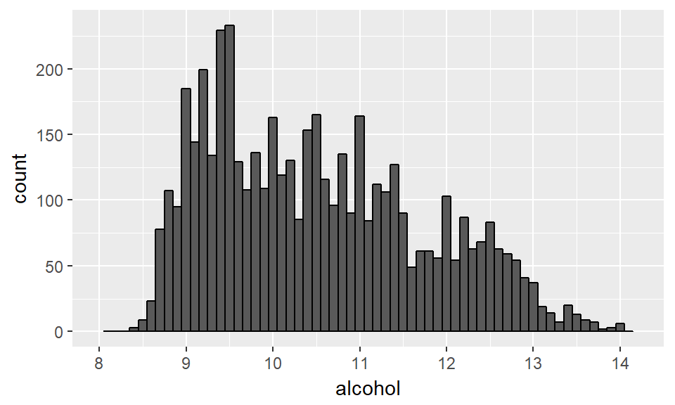

#### What are the distributions of 4-groups or 3-groups variables?

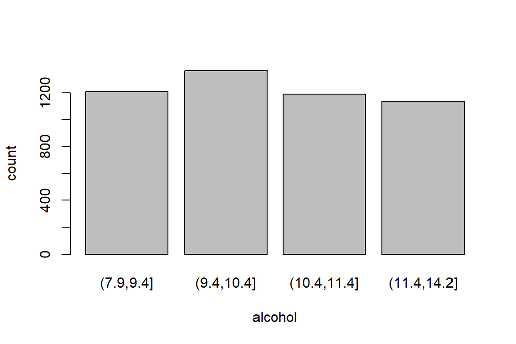

```
## [[1]]
##      [,1]
## [1,]  0.7
## [2,]  1.9
## [3,]  3.1
## [4,]  4.3
##
## [[2]]
## alcohol.group
##   (7.9,9.4]  (9.4,10.4] (10.4,11.4] (11.4,14.2]
##        1208        1365        1190        1135
##
## [[3]]
## [[3]][[1]]
## [1] "% of each group"
##
## [[3]][[2]]
## col
##   (7.9,9.4]  (9.4,10.4] (10.4,11.4] (11.4,14.2]
##    24.66313    27.86852    24.29563    23.17272
```

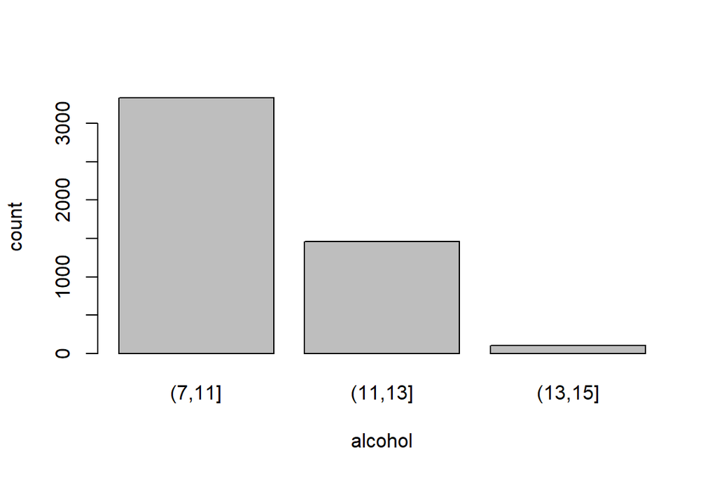

```
## [[1]]
##      [,1]
## [1,]  0.7
## [2,]  1.9
## [3,]  3.1
##
## [[2]]
## alcohol.group
##  (7,11] (11,13] (13,15]
##    3337    1459     102
##
## [[3]]
## [[3]][[1]]
## [1] "% of each group"
##
## [[3]][[2]]
## col
##    (7,11]   (11,13]   (13,15]
## 68.129849 29.787668  2.082483
```

The distributions of < 9.5, 9.5-10.4, 10.5-11.4, and >11.4 are even, so I created a new variable called **alcohol.bucket**, which separated alcohol content into 4 groups.

Additionally, as a conventionally rule, light-bodied wines are 7-11 % alcohol, medium run 11-13%, and full-bodied are over 13%. The body of the wine is how it feels in your mouth. When a wine is full-bodied, it completely coats the palate and tends to feel heavier in the mouth. Also, the texture of the wine either smooth/velvety or coarse/brash contributes to feeling in the mouth. In addition to alcohol.bucket, I created a new variable called **alcohol.body**, which separated alcohol content into 3 groups. The distriubtion of conventional way cutoff was imbalanced, with mostly (68%) being light-bodied (alcohol <= 11).

### Sugar content

#### How the residual.sugar variable is distributed? Any new variables are needed?

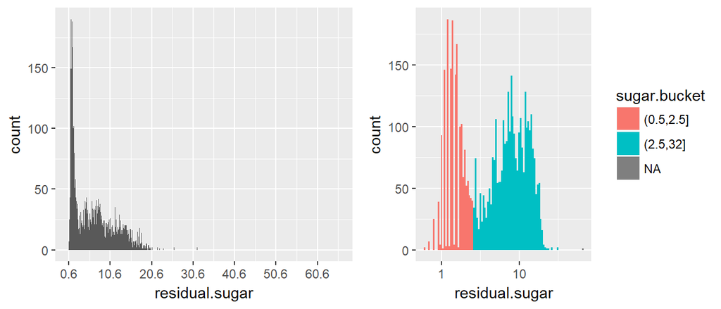

```
## [[1]]
## [1] "% of each group"
##
## [[2]]
## col
## (0.5,2.5]  (2.5,32]
##  35.40220  64.57738
```

The distribution of residual sugar content is skewed with a right long tail. Thus, the log10 transformation helps better understand the distribution of sugar content. It appears to be bimodal with sugar content peaking at around 1.5 or so and again at 8 g/L or so. I created a new variable called **sugar.bucket**, which separated sugar content into 2 groups: <=2.5 (35%) and >2.5 (65%).

According to [data info notes](https://s3.amazonaws.com/udacity-hosted-downloads/ud651/wineQualityInfo.txt), it is rare to find wines with less than 1 g/L of sugar. And wines with greater than 45 g/L sugar are considered sweet.

#### What percentage of white wines are sugar content less than 1 g/L sugar or greater than 45 g/L sugar?

```
## [1] 1.57207
```

```
## [1] 0.0204165
```

The white wine less than 1 g/L is 1.6% of the total. And sweet white wine is only 0.02% of the total, which is very small. I am not sure if “Vinho Verde” white wines are not sweet in general, or if the cutoff of sugar content is more for red wine in general.

#### How the sugar contents are distributed for red wines?

```
##    Min. 1st Qu.  Median    Mean 3rd Qu.    Max.
##   0.900   1.900   2.200   2.539   2.600  15.500
```

Just quick overviewing the stats of residual sugar content from red wines, the Midian is 2.2 and the max is 15.5 g/L which are a lot lower than white wines. Thus, the cutoff (45 g/L) of sugar content for sweet wines is not for red wines either.

### NaCl(salt) content

#### How the NaCl content variable is distributed?

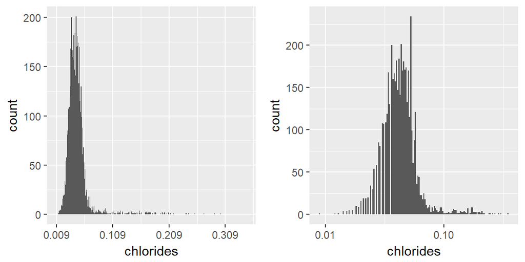

```
##    Min. 1st Qu.  Median    Mean 3rd Qu.    Max.
## 0.00900 0.03600 0.04300 0.04577 0.05000 0.34600
```

```
## [1] 97.75419
```

The distribution of NaCl content is skewed with a right long tail. Thus, the log10 transformation helps better understand the distribution of NaCl content, which looks close to normal. A majority (97.8%) of white wines are less than 0.1 g/L in NaCl content and those between 0.04 and 0.05 are common.

### Density

#### How the density variable is distributed?

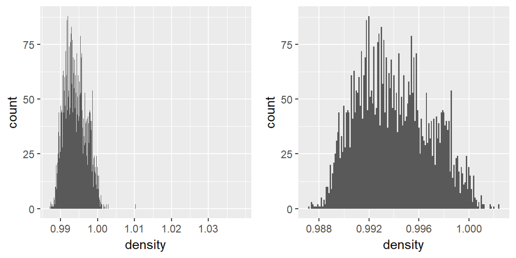

```
##    Min. 1st Qu.  Median    Mean 3rd Qu.    Max.
##  0.9871  0.9917  0.9937  0.9940  0.9961  1.0390
```

```
## [1] 1.939567
```

The lightest and heaviest wines are 0.9871 and 1.0390 Kg/L in density, respectively. Most white wines are between 0.9917 and 0.9961 Kg/L in density. Although the distribution is skewed to the right, log or square root transformations did not improve normality. Excluding top 0.1% helps to better understand the distribution. Density possibly contributes to taste of wine. Density depends on the alcohol and sugar contents. The wines heavier than or equal to water (1 Kg/L) are rare (1.9%).

### Acidity including pH, fixed.acidity, volatile.acidity, and citric.acid

#### pH

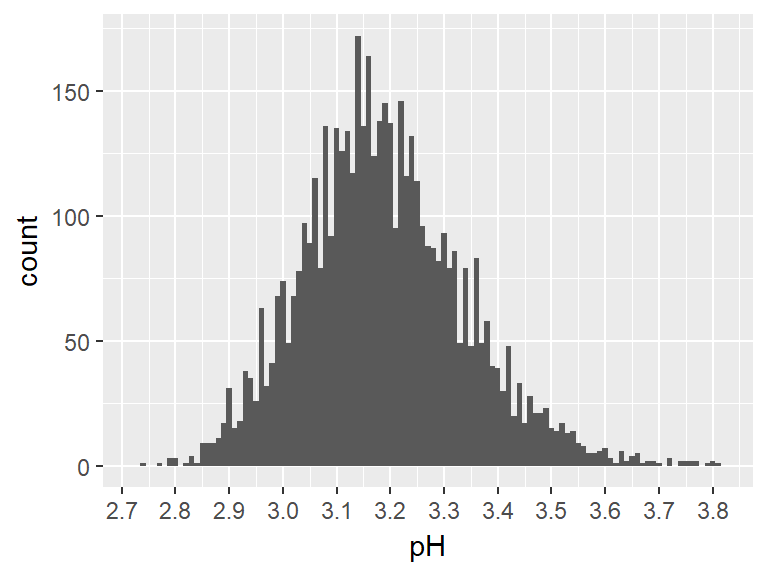

```
##    Min. 1st Qu.  Median    Mean 3rd Qu.    Max.
##   2.720   3.090   3.180   3.188   3.280   3.820
```

#### tartaric acid content (nonvolatile or fixed acidity)

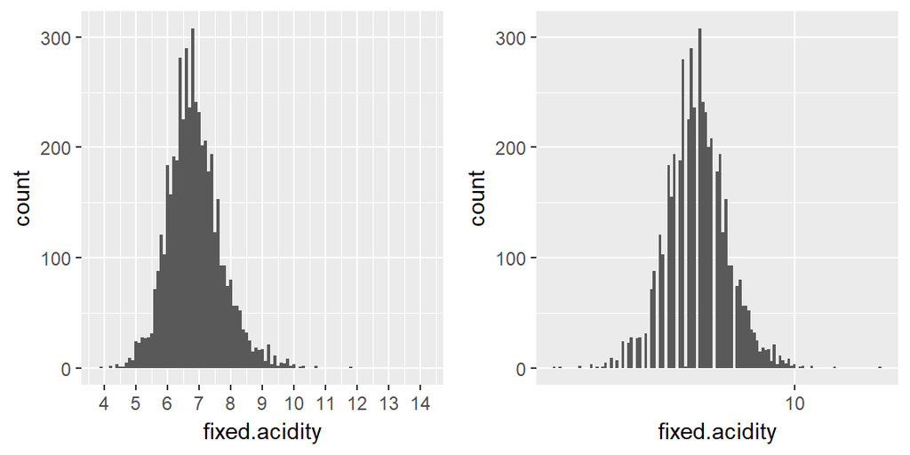

```
##    Min. 1st Qu.  Median    Mean 3rd Qu.    Max.
##   3.800   6.300   6.800   6.855   7.300  14.200
```

#### acetic acid content (volatile acidity)

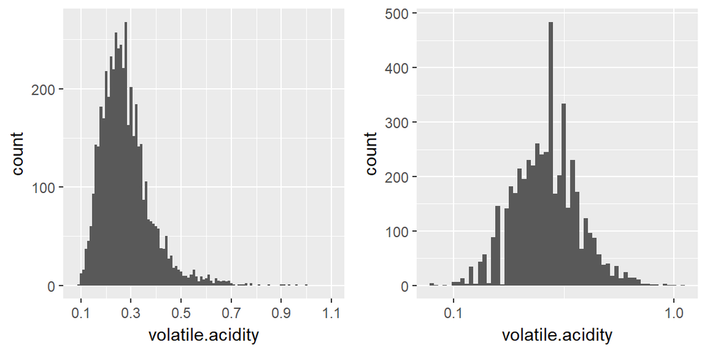

```
##    Min. 1st Qu.  Median    Mean 3rd Qu.    Max.
##  0.0800  0.2100  0.2600  0.2782  0.3200  1.1000
```

#### citric acid content

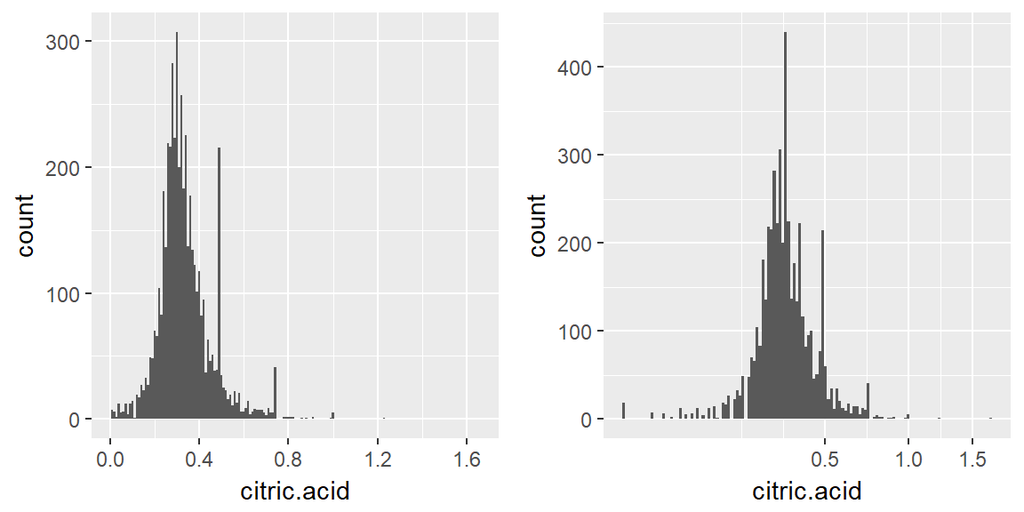

```
## [1] "Count and proportion of 0"
```

```
##    Mode   FALSE    TRUE    NA's
## logical    4879      19       0
```

```
## [1] Inf
```

```
## [1] "Count and proportion of 0.49"
```

```
##    Mode   FALSE    TRUE    NA's
## logical    4683     215       0
```

```
## [1] Inf
```

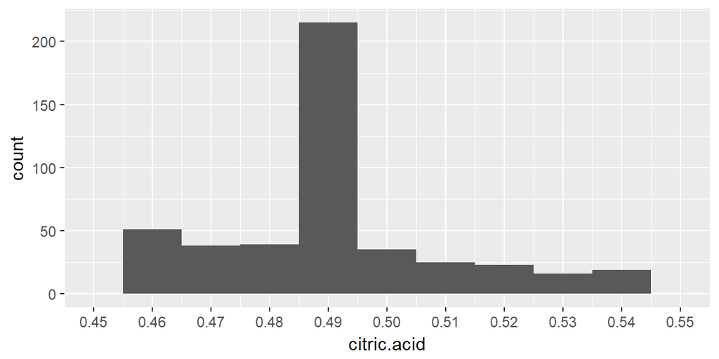

1. pH is already in log term so the distribution is normal. The lowest and the highest in pH of white wine are 2.72 and 3.82, respectively. The most common pH was between 3.1 and 3.3.
2. tartaric acid: the lowest and highest in tartaric acid content are 3.8 and 14.2 g/L, respectively. Most white wines are between 6.3 and 7.3 g/L in tartaric acid.
3. acetic acid: the lowest and highest in acetic acid content are 0.08 and 1.1 g/L, respectively. Most white wines are between 0.21 and 0.32 g/L in acetic acid.
4. citric acid: the lowest and highest in citric acid content are 0 and 1.66 g/L, respectively. There are 19 zeros. Most white wines are between 0.27 and 0.39 g/L in citric acid. There is unusual high count at 0.49 g/L.

Because the distributions of the three acid variables are skewed to the right, log transformation helps to get better distribution for tartaric and acetic acids, and the values of citric acid (having zeros) are square root transformed.

According to the [data info notes](https://s3.amazonaws.com/udacity-hosted-downloads/ud651/wineQualityInfo.txt), excess amount of acetic acid can cause an unpleasant and vinegar taste, while citric acid can add freshness and flavor to wines. Thus, the 4 variables indicating acidity of wine are likely related to each other as well as to wine quality.

### Antimicrobial and antioxidant contents, including sulphates, total.sulfur.dioxide, and free.sulfur.dioxide

#### K2SO4 content (potassium sulphate)

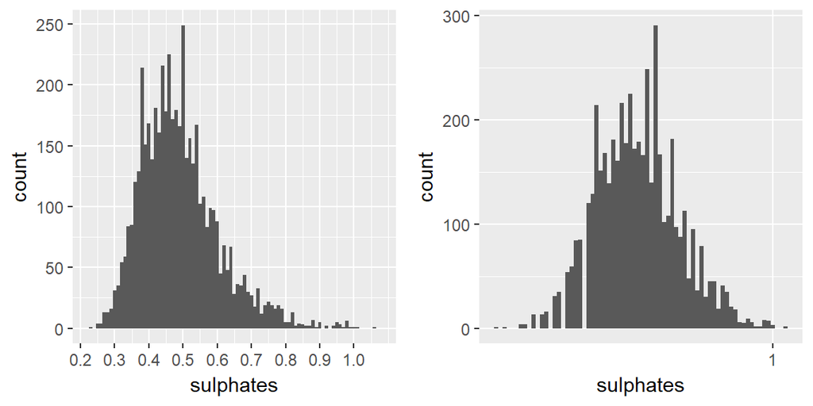

```
##    Min. 1st Qu.  Median    Mean 3rd Qu.    Max.
##  0.2200  0.4100  0.4700  0.4898  0.5500  1.0800
```

#### Total SO2 content

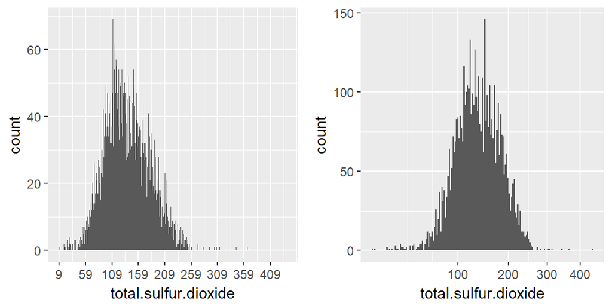

```
##    Min. 1st Qu.  Median    Mean 3rd Qu.    Max.
##     9.0   108.0   134.0   138.4   167.0   440.0
```

#### Free SO2 content

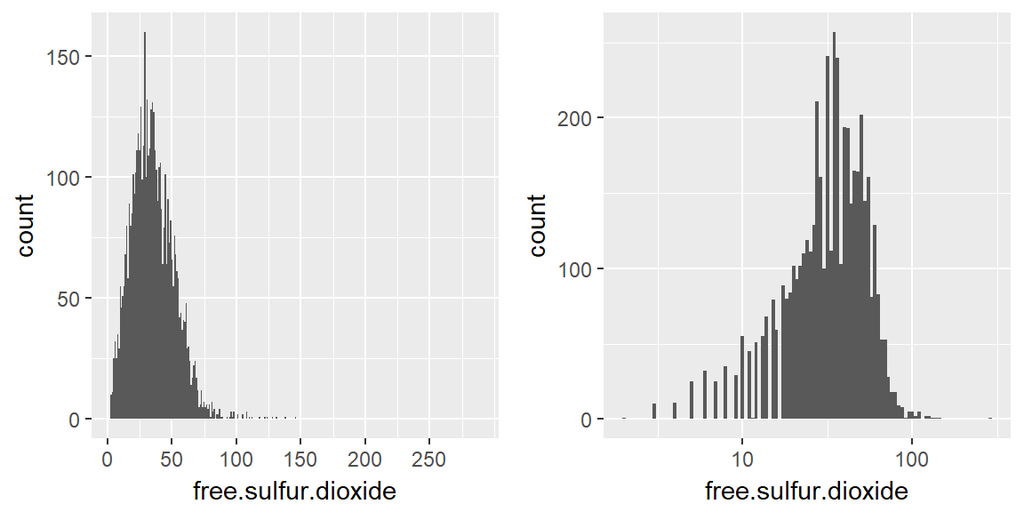

```
##    Min. 1st Qu.  Median    Mean 3rd Qu.    Max.
##    2.00   23.00   34.00   35.31   46.00  289.00
```

```
##    Mode   FALSE    TRUE    NA's
## logical    4030     868       0
```

```
## [1] 17.72152
```

1. sulphates: the lowest and highest in sulphates content are 0.22 and 1.08 g/L, respectively. Most white wines are between 0.41 and 0.55 g/L in sulphates.
2. total SO2: the lowest and highest in total SO2 content are 9 and 440 mg/L, respectively. Most white wines are between 108 and 167 mg/L in total SO2.
3. free SO2: the lowest and highest in free SO2content are 2 and 289 mg/L, respectively. Most white wines are between 23 and 46 mg/L in free SO2.

Because the distributions of all three variables are skewed to the right, log transformation helps to get better distribution for sulphates and free SO2. And the values of total SO2 are square root transformed.

According to the [data info notes](https://s3.amazonaws.com/udacity-hosted-downloads/ud651/wineQualityInfo.txt), free SO2 prevents microbial growth and the oxidation of wine, but over 50 mg/L of free SO2 (about 18%), SO2 becomes evident in the nose and taste of wine. Thus, free SO2 is likely related to wine quality. In addition, sulfates are an additive that contributes to SO2 gas, and so all three variables indicating sulfur content are likely related to each other.

## 2.1.2 Univariate Analysis

### What is the structure of your dataset?

There were 4,898 white wines in the dataset with 1 sensory data (quality score) and 11 physicochemical properties (alcohol, sugar, NaCl, tartaric acid, acetic acid, citric acid, K2SO4, total and free SO2 contents, pH, and density). All physicochemical properties were numeric variables, and the quality variable was integer.

Other observations: - The most common white wines were quality score of 6. - Alcohol content ranged from 8 to 14.2% and the median alcohol was 10.4%. - Sugar content ranged from 0.6 to 65.8 g/L and most white wines were around 2 and 10 g/L. - Salt content was less than 0.1 g/L for most white wines (98%) with the median of 0.043 g/L. - Density ranged from 0.9871 to 1.0390 Kg/L with the median of 0.9937 Kg/L. - Acidity ranged from pH 2.72 to pH 3.82 with the median of pH 3.18. - The medians of tartaric, acetic, and citric acid contents were 6.8, 0.26, and 0.32 g/L, respectively. - The medians of K2SO4, total and free SO2 contents were 0.47 g/L, 134 mg/L, and 34 mg/L, respectively.

### What is/are the main feature(s) of interest in your dataset?

The main feature in the data set was quality score. I would like to determine which physicochemical properties (input variables) are best for predicting the quality of white wine (output variable). The measurements of physicochemical properties could be responsible for smell and taste of white wine. For examples, sugar for sweetness, NaCl for saltiness, acidity for sourness, acetic acid for vinegary taste, citric acid for citrus flavor, and free SO2 for pungent odor. I think that the balance among these flavors can contribute to the wine quality, thus some combination of physicochemical properties can be used to complement sensory tests or build a predictive model to sensory tests.

### What other features in the dataset do you think will help support your investigation into your feature(s) of interest?

The article (Cortez 2009) hinted that there is relationship between alcohol and residual sugar contents since alcohol production depends on grape sugar level and fermentation process. After reading some basics about wine tasting, too much or too little of alcohol, sweets, acids are not preferred and balancing among the ingredients is required for good quality. Focusing on high quality wines to compare how physicochemical properties of high quality wines are distributed differently from the others might help to understand any consistent trends for high quality.

### Did you create any new variables from existing variables in the dataset?

I created 6 new variables including quality.order, quality.con, quality.lib, alcohol.bucket, alcohol.body, sugar.bucket.

- quality.order is a variable changed from existing variable quality, which was numeric, to ordered factor with 7 levels.
- quality.con is a variable also changed from variable quality, by cutting into evenly distributed 3 levels.
- quality.lib is a variable also changed from variable quality, by cutting into unproportionally distributed 3 levels.
- alcohol.bucket is a variable changed from existing variable alcohol, by evenly cutting numbers into 4 levels.
- alcohol.body is a variable also changed from alcohol to 3-leveled categoroy, by following conventional body levels of wines.
- sugar.bucket is a variable changed from existing variable residual.sugar and separated into 2 levels guided by bimodal distribution.

Reasoning: ordered or categorical factors are useful to color data as well as draw statistics on plots for further analysis.

### Of the features you investigated, were there any unusual distributions? Did you perform any operations on the data to tidy, adjust, or change the form of the data? If so, why did you do this?

I log- or square root-transformed the right skewed distributions. The distributions of NaCl, sugar, tartaric and acetic acids, K2SO4, free SO2 were strongly skewed to the right, so log-transformation was used to reduce the strong right skewness. The transformed distribution for sugar appeared bimodal with the sugar peaking at around 1.5 or so and again at 8 g/L or so. Some wines had zero values of citric acid, so square root transformation was applied to reduce the right skewness for citric acid. The distribution of total SO2 was weakly skewed, so squared root transformation was used.

## 2.2.1 Bivariate Plots Section

### Multivariate Outliers

I will use multivariate approach to detect outliers instead of looking at all pairs of variables using ww_subset. This way I can detect universal outliers shown across all the variables. But there might be more detectable outliners by pair-wise approach.

#### Is there any outlier?

**chi square plot of ww_subset before removing any outlier**

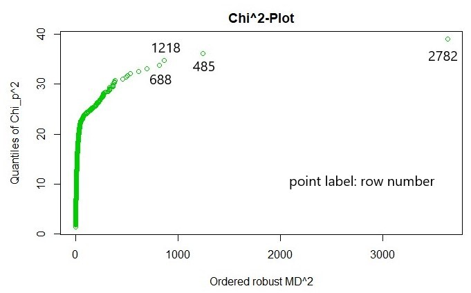

chisq.plot

Observations left out: 2782

The outlier detected is X = 2782 with Sq. Mahalanobis Distance (MD) of 3800.

#### What are the values of variables for X=2782?

```
##         X fixed.acidity volatile.acidity citric.acid residual.sugar
## 2782 2782           7.8            0.965         0.6           65.8
##      chlorides free.sulfur.dioxide total.sulfur.dioxide density   pH
## 2782     0.074                   8                  160 1.03898 3.39
##      sulphates alcohol quality quality.order quality.con quality.lib
## 2782      0.69    11.7       6             6       (5,6]       (4,7]
##      alcohol.bucket alcohol.body sugar.bucket
## 2782    (11.4,14.2]      (11,13]         <NA>
```

Observation 2782 has extreme values in acetic acid, sugar, and density, and the values of the other variables are far from the medians. I decided to delete this row.

```
## [1] "Dimensions of dataframe, ww"
```

```
## [1] 4897   19
```

```
## [1] "Dimensions of dataframe, ww_subset"
```

```
## [1] 4897   12
```

Now, the dataframes have 4897 observations.

**chi square plot of ww_subset after removing the first outlier**

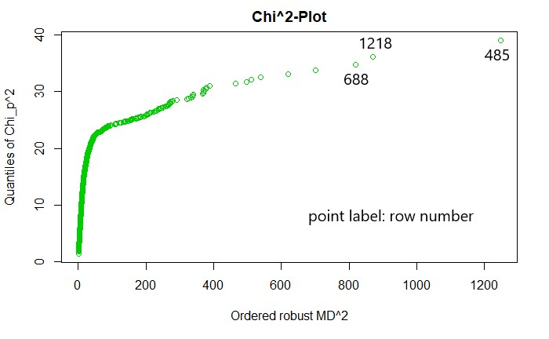

chisq.plot

The maximum Sq. MD decreases from 3800 to 1200.

#### What are the values of variables for X=485?

```
##       X fixed.acidity volatile.acidity citric.acid residual.sugar
## 485 485           6.2             0.37         0.3            6.6
##     chlorides free.sulfur.dioxide total.sulfur.dioxide density   pH
## 485     0.346                  79                  200  0.9954 3.29
##     sulphates alcohol quality quality.order quality.con quality.lib
## 485      0.58     9.6       5             5       (2,5]       (4,7]
##     alcohol.bucket alcohol.body sugar.bucket
## 485     (9.4,10.4]       (7,11]     (2.5,32]
```

Although it seems very good improvement in dereasing Sq. MD, the cutoff of Sq. MD value can be little bit arbitrary. So, I decide to keep the next outlier (X=485) by looking at its values. Only NaCl is extreme value and the values of other variables are not considered as extreme. And I think this particular data point is valuable to keep.

I have noticed that the columns’ names are too long for such scatterplot matrix so I will rename all the columns for simplicity and readability on the plots.

```r
# Rename variables
ww_subset <- rename(ww_subset,
       c("alcohol" = "alco",
         "residual.sugar" = "sugar",
         "chlorides" = "NaCl",
         "density" = "dens",
         "fixed.acidity" = "tart",
         "volatile.acidity" = "acet",
         "citric.acid" = "citr",
         "sulphates" = "K2SO4",
         "free.sulfur.dioxide" = "fSO2",
         "total.sulfur.dioxide" = "tSO2",
         "quality" = "qual"))
```

I will generate a new dataframe that includes log- or square root-transformed data according to the univariate analysis results.

```r
# Create another dataframe including transformed data
tart.log <- log10(ww_subset$tart)
acet.log <- log10(ww_subset$acet)
citr.sqrt <- sqrt(ww_subset$citr)
suga.log <- log10(ww_subset$sugar)
NaCl.log <- log10(ww_subset$NaCl)
fSO2.log <- log10(ww_subset$fSO2)
tSO2.sqrt <- sqrt(ww_subset$tSO2)
dens <- ww_subset$dens
pH <- ww_subset$pH
SO4.log <- log10(ww_subset$K2SO4)
alco <- ww_subset$alco
qual <- ww_subset$qual

ww_trans <- data.frame(alco, suga.log, NaCl.log, dens,
                       pH, tart.log, acet.log, citr.sqrt,
                       SO4.log, tSO2.sqrt, fSO2.log, qual)
```

#### What does chi-square plot look like after variable transformation?

**chi square plot of ww_trans**

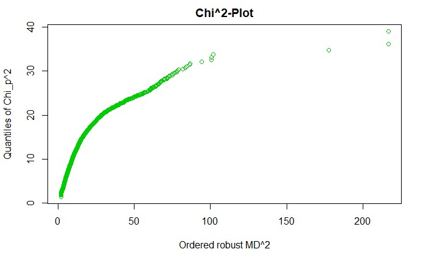

chisq.plot

**chi square plot of ww_trans without suga.log**

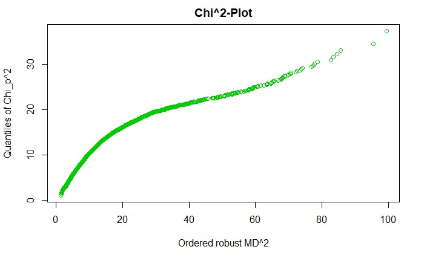

chisq.plot

I notice a great difference in range of x-axis where the range of Sq MD decreases from 1200 to 200. By transforming variables, it helps reduce overall outliers, plus plotting it without sugar variable improves a lot (Sq. MD around 100).

### Numeric variables analysis: regressions

### Correlation Matrix

#### What pairs of variables have strong correlations?

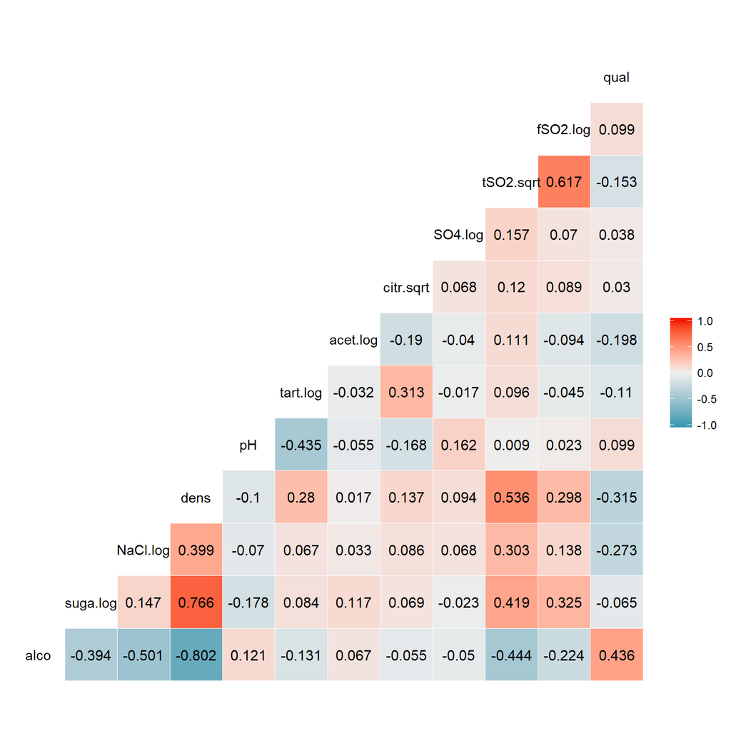

**Summary of findings from correlation matrix:**

- The main feature of interest is quality. Alcohol, density, NaCl, acetic acid, and total SO2 seem to have medium to weak correlation with quality score.
- Other than main features, density is an interesting variable, which has strong correlations with alcohol, sugar, and total SO2 and weak correlations with NaCl, free SO2, and tartaric acid.
- Alcohol is correlated with NaCl, total SO2, sugar, and free SO2.
- pH is correlated with tartaric and citric acid and K2SO4, but not with acetic acid.
- Citric acid was weakly correlated with tartaric and acetic acids.
- Free and total SO2 was strongly correlated.
- Sugar was correlated with free and total SO2.
- NaCl and total SO2 weakly were correlated.

### Correlation Network Matrix

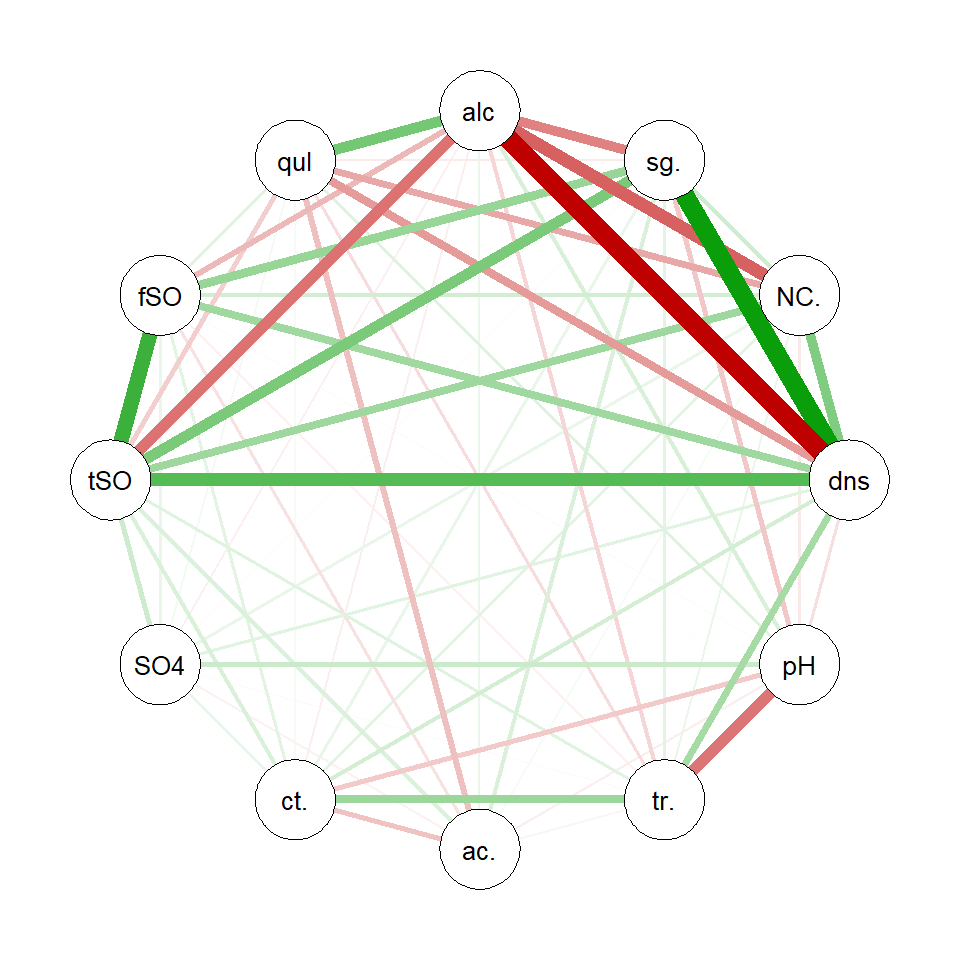

```
## [1] "Correlation Coefficient 0.2 or higher"
```

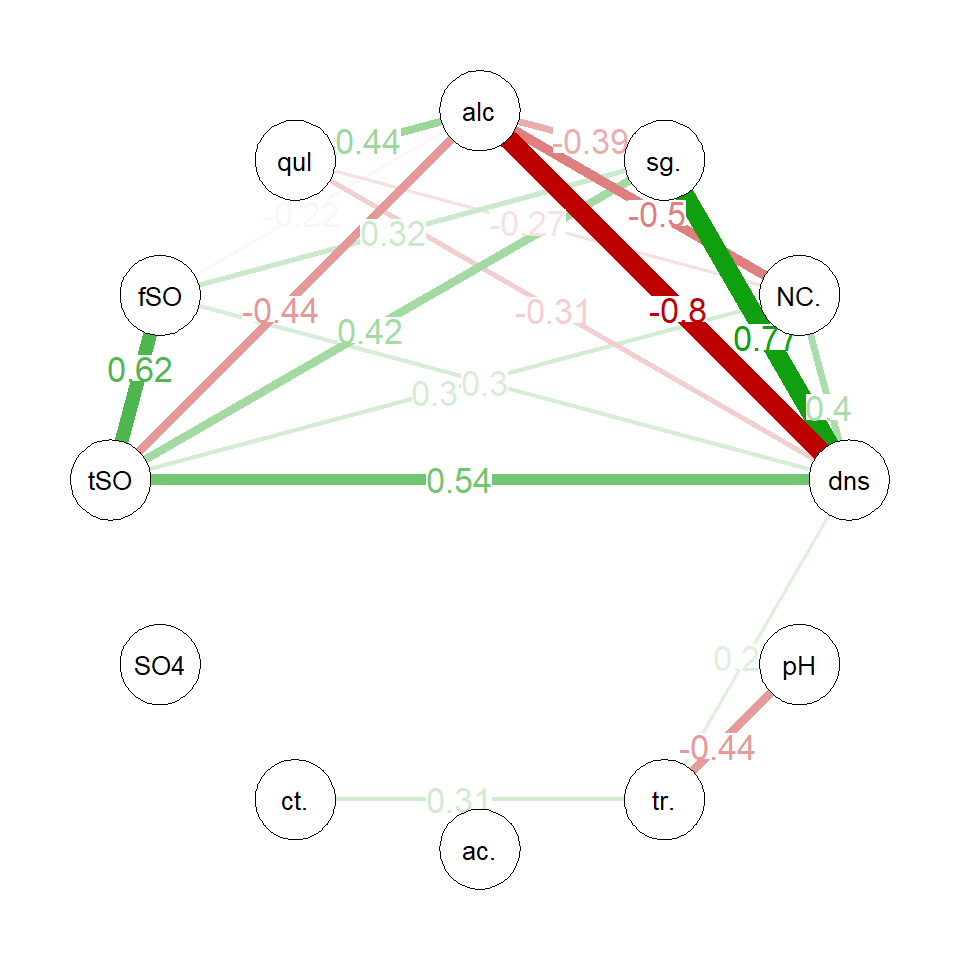

#### What are the r-square values between quality vs. alcohol and quality vs. density?

```
##
## Calls:
## qual.alco1: lm(formula = quality ~ alcohol, data = ww)
## qual.alco2: lm(formula = quality ~ alcohol, data = ww[ww$quality > 4, ])
## qual.dens: lm(formula = quality ~ density, data = ww)
##
## ======================================================
##                   qual.alco1  qual.alco2  qual.dens
## ------------------------------------------------------
##   (Intercept)      2.582***    2.740***   100.779***
##                   (0.098)     (0.089)      (4.088)
##   alcohol          0.314***    0.305***
##                   (0.009)     (0.008)
##   density                                 -95.473***
##                                            (4.113)
## ------------------------------------------------------
##   R-squared           0.190       0.219       0.099
##   adj. R-squared      0.190       0.218       0.099
##   sigma               0.797       0.714       0.841
##   F                1146.259    1318.586     538.819
##   p                   0.000       0.000       0.000
##   Log-likelihood  -5838.650   -5098.401   -6098.118
##   Deviance         3112.194    2400.672    3460.103
##   AIC             11683.300   10202.801   12202.236
##   BIC             11702.789   10222.176   12221.725
##   N                4897        4714        4897
## ======================================================
```

Alcohol can explain 19% of the variance in quality score and density can 10%. The subset of data with quality higher than 4 shows that alcohol can explain 22% of the variance in quality.

### Categorical variable analysis: boxplot or density plot

### Boxplots grouped by quality.con

I will create boxplots of all physicochemical properties grouped by quality.cons (<6, 6, >6) to find general trends. Firstly, I will look at the boxplots of all variables and then I will investigate further on individual variable vs. quality if any interesting trend is shown.

#### Is there any noticeable trend from low and middle to high quality, which was not detected from correlation analysis?

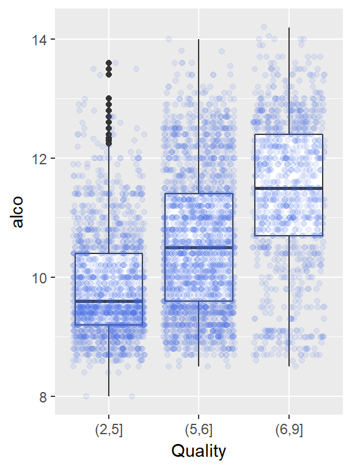

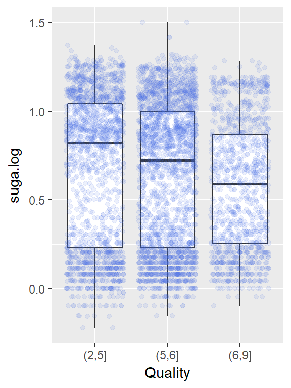

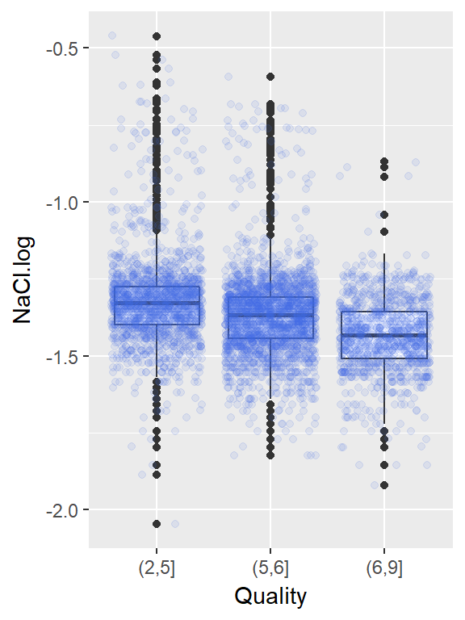

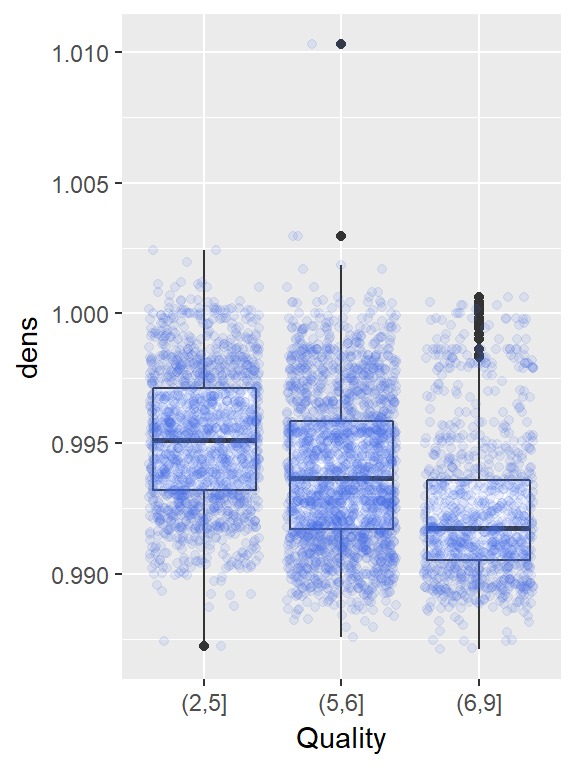

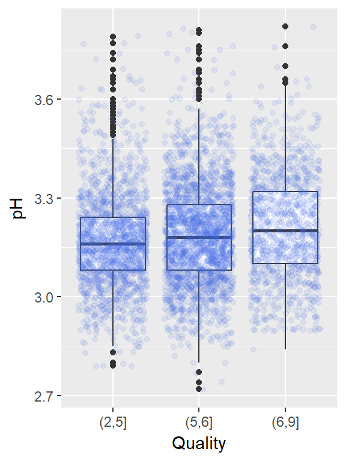

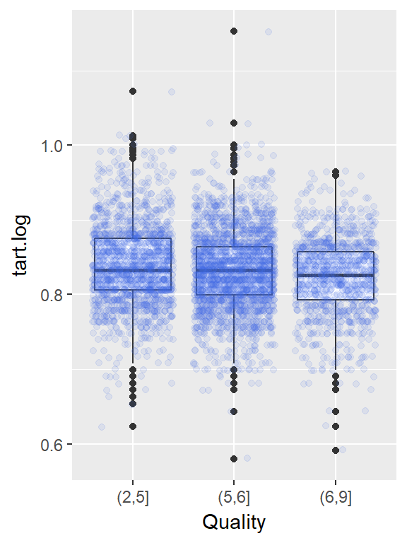